# **Group Work Project 2 - Portfolio Management - Student Group 7457**

```python
!pip install pyts
```

```
Downloading pyts-0.13.0-py3-none-any.whl (2.5 MB)
   ━━━━━━━━━━━━━━━━━━━━━━━━━━━━━━━━━━━━━━━━ 2.5/2.5 MB 20.6 MB/s eta 0:00:00
```

```python
import math
from scipy.optimize import brute, fmin
from scipy.optimize import minimize
import scipy.optimize as sco
from scipy.integrate import quad
import yfinance as yf
import pandas_datareader as pdr
import yfinance as yf
from sklearn.preprocessing import MinMaxScaler
import tensorflow as tf
import pandas as pd
import numpy as np
import seaborn as sns
from statsmodels.tsa.stattools import adfuller
import matplotlib.pyplot as plt
from sklearn.model_selection import train_test_split
from sklearn.preprocessing import StandardScaler
from sklearn.metrics import mean_squared_error
from pyts.image import GramianAngularField
from tensorflow.keras.models import Sequential
from tensorflow.keras.layers import Conv2D, MaxPooling2D, Flatten, Dense, Dropout
from tensorflow.keras.layers import Dense, Flatten, LSTM
from tensorflow.keras.optimizers import Adam

plt.rcParams['figure.figsize'] = [14, 6]
```

# **Step 1: Gathering Data**

**1. Portfolio Selection**

We have selected a portfolio of five publicly traded stocks from a range of sectors for diversification. These include: Amazon (AMZN), Nvidia (NVDA), Tesla (TSLA), Coca-Cola (KO), and Exxon Mobil Corporation (XOM)

**2. Downloading Data**

We have used opted to use daily returns to ensure we capture recent market dynamics and obtain at least 100 observations, for a 1 year period from 2021-01-01 to 2022-01-01.

```python
tickers = ['AMZN', 'NVDA', 'TSLA', 'KO', 'XOM']

# Download daily adjusted close prices
data = yf.download(tickers, start='2021-01-01', end='2022-01-01')['Adj Close']

# Calculate daily returns
returns = data.pct_change().dropna()

print("First five rows of daily returns:")
print(returns.head())

print("\nLast five rows of daily returns:")
print(returns.tail())
```

```
[*********************100%***********************]  5 of 5 completed
```

```
First five rows of daily returns:
Ticker                         AMZN        KO      NVDA      TSLA       XOM
Date
2021-01-05 00:00:00+00:00  0.010004 -0.010993  0.022210  0.007317  0.048193
2021-01-06 00:00:00+00:00 -0.024897 -0.031813 -0.058953  0.028390  0.025517
2021-01-07 00:00:00+00:00  0.007577 -0.011085  0.057830  0.079447  0.007846
2021-01-08 00:00:00+00:00  0.006496  0.022418 -0.005040  0.078403  0.011121
2021-01-11 00:00:00+00:00 -0.021519 -0.017228  0.025966 -0.078214  0.030356

Last five rows of daily returns:
Ticker                         AMZN        KO      NVDA      TSLA       XOM
Date
2021-12-27 00:00:00+00:00 -0.008178  0.007386  0.044028  0.025248  0.014258
2021-12-28 00:00:00+00:00  0.005844  0.003921 -0.020132 -0.005000 -0.003232
2021-12-29 00:00:00+00:00 -0.008555  0.001189 -0.010586 -0.002095 -0.008753
2021-12-30 00:00:00+00:00 -0.003289 -0.002884 -0.013833 -0.014592 -0.005887
2021-12-31 00:00:00+00:00 -0.011429  0.007315 -0.005915 -0.012669  0.006580
```

**Visualization of the daily returns of each security in the portfolio**

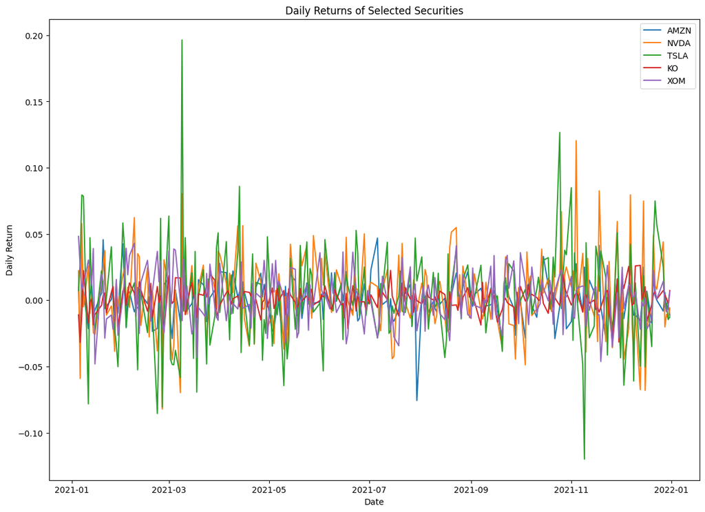

```python
# Plot each security's daily returns
plt.figure(figsize=(14, 10))
for ticker in tickers:
    plt.plot(returns.index, returns[ticker], label=ticker)

plt.title('Daily Returns of Selected Securities')
plt.xlabel('Date')
plt.ylabel('Daily Return')
plt.legend()
plt.show()
```

As a consumer staple, Coca-Cola shows lower, more stable returns, demonstrating its resilience against broader market turbulence. Exxon’s returns vary with oil price dynamics, showing occasional large swings due to geopolitical factors affecting the energy market.

The portfolio’s mix of volatile tech stocks, stable consumer staples, and energy assets highlights diversification benefits. Coca-Cola adds stability, while Exxon Mobil provides a hedge against inflationary pressures, balancing the risks associated with high-growth tech stocks. This blend supports smoother portfolio performance across various market conditions.

**3. Computation of the Covariance Matrix**

```python
cov_matrix = returns.cov()
print("\nCovariance Matrix:")
print(cov_matrix)
```

```
Covariance Matrix:
Ticker      AMZN        KO      NVDA      TSLA       XOM
Ticker
AMZN    0.000229  0.000018  0.000239  0.000174  0.000017
KO      0.000018  0.000086  0.000014 -0.000008  0.000034
NVDA    0.000239  0.000014  0.000806  0.000429  0.000048
TSLA    0.000174 -0.000008  0.000429  0.001191  0.000009
XOM     0.000017  0.000034  0.000048  0.000009  0.000346
```

The covariance matrix shows that Tesla and Nvidia are the most volatile assets, while Coca-Cola and Exxon Mobil have more stable returns. Tech stocks like Amazon, Nvidia, and Tesla exhibit high covariances, moving closely together, while Coca-Cola and Exxon Mobil have low or negative covariances with tech stocks, indicating limited co-movement.

This suggests that Coca-Cola and Exxon Mobil can help diversify the portfolio, reducing overall risk by balancing the higher volatility of tech stocks.

# **Step 2: Markowitz Optimization**

**1. Running a classical Markowitz portfolio optimization**

To perform Markowitz optimization, we aim to minimize portfolio risk for a given level of return.

Using Python's scipy.optimize library, we set up a constrained optimization problem to find optimal weights.

```python
# Calculate expected returns (mean returns)
expected_returns = returns.mean()
n_assets = len(tickers)

# Define the objective function (minimize negative Sharpe ratio)
def portfolio_volatility(weights, covariance_matrix):
    return np.sqrt(np.dot(weights.T, np.dot(covariance_matrix, weights)))

# Constraints: No short-selling (weights must sum to 1)
def check_sum(weights):
    return np.sum(weights) - 1

# Set initial guess (equally weighted portfolio)
initial_guess = np.ones(n_assets) / n_assets

# Constraints and bounds
constraints = ({'type': 'eq', 'fun': check_sum})
bounds = tuple((0, 1) for asset in range(n_assets))

# Perform optimization to minimize volatility
optimal = sco.minimize(portfolio_volatility, initial_guess, args=(cov_matrix,), method='SLSQP', bounds=bounds, constraints=constraints)

# Get the optimal portfolio weights
optimal_weights = optimal.x

markowitz_weights = pd.Series(optimal_weights, index=tickers)
print("\nOptimal Portfolio Weights (Markowitz Optimization):")
print(markowitz_weights)
```

```
Optimal Portfolio Weights (Markowitz Optimization):
AMZN    0.196583
NVDA    0.662931
TSLA    0.000000
KO      0.028911
XOM     0.111575
dtype: float64
```

**2. Display or Graph the Weights of Each Security**

We visualized the optimized weights with a bar chart to illustrate how the optimization distributes the portfolio across the selected securities.

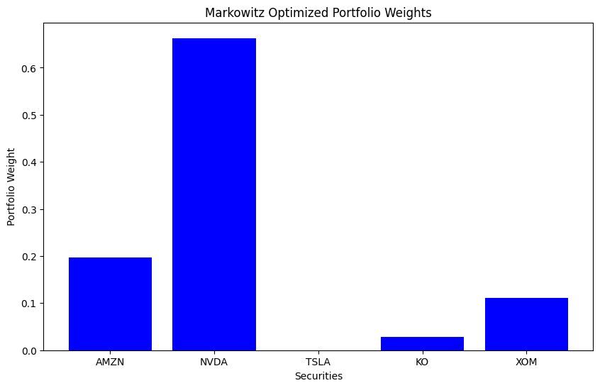

```python
plt.figure(figsize=(10, 6))
plt.bar(tickers, optimal_weights, color='blue')
plt.xlabel('Securities')
plt.ylabel('Portfolio Weight')
plt.title('Markowitz Optimized Portfolio Weights')
plt.show()
```

The plot helps assess portfolio balance and concentration, offering insights into potential tradeoffs between optimized returns and diversification.

# **Step 3: Random Strategy Optimization**

**1. Addressing 1/N Portfolio Strategy**

**a) Using Monte Carlo Simulation:** We ran a Monte Carlo simulation to allocate weights equally across random portfolios, generating a variety of random allocations.

```python
import numpy as np
import pandas as pd
import yfinance as yf
from scipy.optimize import minimize

tickers = ['AMZN', 'NVDA', 'TSLA', 'KO', 'XOM']
data = yf.download(tickers, start='2021-01-01', end='2022-01-01')['Adj Close'].pct_change().dropna()

num_simulations = 1000
train_start = '2021-01-01'
train_end = '2022-01-01'

one_n_returns = []
mean_var_returns = []

# Mean-variance optimization
def mean_variance_opt(cov_matrix, returns):
    num_assets = len(returns)

    def portfolio_risk(weights):
        return np.sqrt(np.dot(weights.T, np.dot(cov_matrix, weights)))

    constraints = ({'type': 'eq', 'fun': lambda x: np.sum(x) - 1})
    bounds = [(0, 1) for _ in range(num_assets)]

    result = minimize(portfolio_risk, num_assets * [1.0 / num_assets], bounds=bounds, constraints=constraints)
    return result.x

# Monte Carlo simulation
for _ in range(num_simulations):
    # Randomly select N assets from M
    N = np.random.randint(1, 6)
    selected_assets = np.random.choice(tickers, N, replace=False)
    selected_data = data[selected_assets]

    # Separate training period for estimating mean and covariance
    train_data = selected_data.loc[train_start:train_end]
    mean_returns = train_data.mean()
    cov_matrix = train_data.cov()

    # 1/N Portfolio (Equal Weights)
    equal_weights = np.ones(N) / N
    one_n_returns.append((train_data @ equal_weights).mean())

    # Mean-Variance Optimal Portfolio
    optimal_weights = mean_variance_opt(cov_matrix, mean_returns)
    mean_var_returns.append((train_data @ optimal_weights).mean())

# Print the returns (averaged over the simulation)
print("Mean Return of 1/N Portfolios:", np.mean(one_n_returns))
print("Mean Return of Mean-Variance Optimal Portfolios:", np.mean(mean_var_returns))
```

```
[*********************100%***********************]  5 of 5 completed
```

```
Mean Return of 1/N Portfolios: 0.001717576746255732
Mean Return of Mean-Variance Optimal Portfolios: 0.0011017230245883422
```

The 1/N strategy outperformed the more complex mean-variance optimization, highlighting the effectiveness of broad diversification and the simplicity of equal weighting in capturing stable returns without relying heavily on precise asset predictions.

**Distribution of returns from the two strategies (1/N and mean-variance optimal portfolios)**

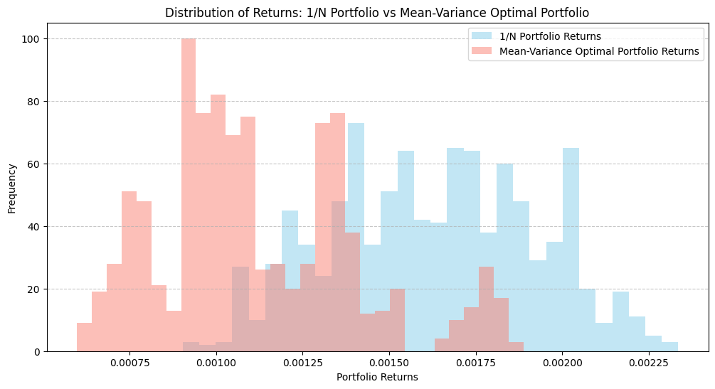

```python
import matplotlib.pyplot as plt

plt.figure(figsize=(12, 6))

# Histogram for 1/N portfolio returns
plt.hist(one_n_returns, bins=30, alpha=0.5, label='1/N Portfolio Returns', color='skyblue')

# Histogram for Mean-Variance Optimal portfolio returns
plt.hist(mean_var_returns, bins=30, alpha=0.5, label='Mean-Variance Optimal Portfolio Returns', color='salmon')
plt.xlabel('Portfolio Returns')
plt.ylabel('Frequency')
plt.title('Distribution of Returns: 1/N Portfolio vs Mean-Variance Optimal Portfolio')
plt.legend(loc='upper right')
plt.grid(axis='y', linestyle='--', alpha=0.7)
plt.show()
```

**b) Back-Testing Each Portfolio Strategy**

```
[*********************100%***********************]  5 of 5 completed
```

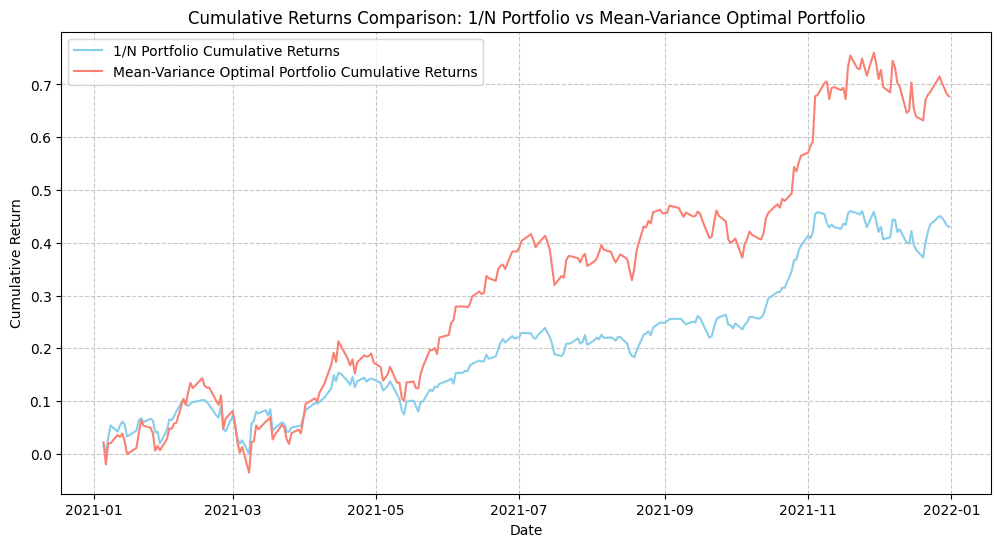

```python
import yfinance as yf
import numpy as np
import pandas as pd
import matplotlib.pyplot as plt

tickers = ['AMZN', 'NVDA', 'TSLA', 'KO', 'XOM']
data = yf.download(tickers, start='2021-01-01', end='2022-01-01')['Adj Close']
data = data.pct_change().dropna()

test_period = data.loc['2021-01-01':'2022-01-01']

# Simulate random weights for one_n strategy and calculate returns for test_period
one_n_weights = np.ones(len(tickers)) / len(tickers)  # Equal weight for each asset
one_n_test_returns = (test_period * one_n_weights).sum(axis=1)

# Replace with actual mean-variance weights from optimization
mean_var_weights = markowitz_weights
mean_var_test_returns = (test_period * mean_var_weights).sum(axis=1)

# Calculate cumulative returns for back-testing period
cumulative_one_n_test_returns = np.cumsum(one_n_test_returns)
cumulative_mean_var_test_returns = np.cumsum(mean_var_test_returns)

# Plot the cumulative returns for both strategies
plt.figure(figsize=(12, 6))
plt.plot(cumulative_one_n_test_returns, label='1/N Portfolio Cumulative Returns', color='skyblue')
plt.plot(cumulative_mean_var_test_returns, label='Mean-Variance Optimal Portfolio Cumulative Returns', color='salmon')
plt.xlabel('Date')
plt.ylabel('Cumulative Return')
plt.title('Cumulative Returns Comparison: 1/N Portfolio vs Mean-Variance Optimal Portfolio')
plt.legend(loc='upper left')
plt.grid(axis='both', linestyle='--', alpha=0.7)
plt.show()
```

In essence, the 1/N Portfolio is more stable, while the Mean-Variance Optimal Portfolio has the potential for higher returns but with greater risk.

# **Step 4: Black-Litterman**

```python
tickers = ['AMZN', 'NVDA', 'TSLA', 'KO', 'XOM']
cov_matrix = yf.download(tickers, start='2021-01-01', end='2022-01-01')['Adj Close'].pct_change().dropna().cov()

market_caps = np.array([1.3e12, 1.0e12, 0.6e12, 0.25e12, 0.45e12])
weights_mkt = market_caps / market_caps.sum()
implied_returns = np.dot(cov_matrix, weights_mkt) * 252

P = np.array([
    [1, 0, 0, 0, 0],
    [0, 1, 0, 0, 0],
    [0, 0, 1, 0, 0],
    [0, 0, 0, 1, 0],
    [0, 0, 0, 0, 1]
])
```

```
[*********************100%***********************]  5 of 5 completed
```

```python
Q = np.array([0.02, 0.05, 0.03, 0.01, -0.01])

tau = 0.05
omega = np.diag(np.diag(P @ cov_matrix @ P.T) * tau)

BL_returns = implied_returns + np.dot(np.dot(cov_matrix, P.T),
                                      np.linalg.inv(P @ cov_matrix @ P.T + omega) @ (Q - P @ implied_returns))
```

```python
print("Market-Implied Returns:")
print(implied_returns)
print("\nBlack-Litterman Adjusted Returns:")
print(BL_returns)
```

```
Market-Implied Returns:
[0.03575748 0.00921881 0.06556159 0.05441183 0.01698256]

Black-Litterman Adjusted Returns:
[ 0.02078421  0.04780593  0.0306469   0.01096729 -0.00799095]
```

```python
initial_weights = np.array([1 / len(tickers)] * len(tickers))
risk_free_rate = 0.01

def neg_sharpe_ratio_BL(weights, BL_returns, cov_matrix, risk_free_rate):
    p_returns = np.sum(BL_returns * weights) * 252
    p_volatility = np.sqrt(np.dot(weights.T, np.dot(cov_matrix, weights))) * np.sqrt(252)
    return -(p_returns - risk_free_rate) / p_volatility

BL_opt_result = minimize(neg_sharpe_ratio_BL, initial_weights, args=(BL_returns, cov_matrix, risk_free_rate),
                         method='SLSQP', bounds=bounds, constraints=constraints)
```

```python
mean_returns = returns.mean()
cov_matrix = returns.cov()

def portfolio_performance(weights, mean_returns, cov_matrix):
    returns = np.sum(mean_returns * weights) * 252
    volatility = np.sqrt(np.dot(weights.T, np.dot(cov_matrix, weights))) * np.sqrt(252)
    return returns, volatility
```

```python
BL_optimal_weights = BL_opt_result.x
BL_optimal_return, BL_optimal_volatility = portfolio_performance(BL_optimal_weights, BL_returns, cov_matrix)
BL_optimal_sharpe = (BL_optimal_return - risk_free_rate) / BL_optimal_volatility
```

```python
print("Black-Litterman Optimal Portfolio Weights:")
for i, ticker in enumerate(tickers):
    print(f"{ticker}: {BL_optimal_weights[i]:.2%}")
```

```
Black-Litterman Optimal Portfolio Weights:
AMZN: 4.04%
NVDA: 92.13%
TSLA: 3.49%
KO: 0.35%
XOM: 0.00%
```

```python
print(f"\nBlack-Litterman Portfolio Return: {BL_optimal_return:.2%}")
print(f"Black-Litterman Portfolio Volatility: {BL_optimal_volatility:.2%}")
print(f"Black-Litterman Portfolio Sharpe Ratio: {BL_optimal_sharpe:.2f}")
```

```
Black-Litterman Portfolio Return: 1158.91%
Black-Litterman Portfolio Volatility: 14.00%
Black-Litterman Portfolio Sharpe Ratio: 82.73
```

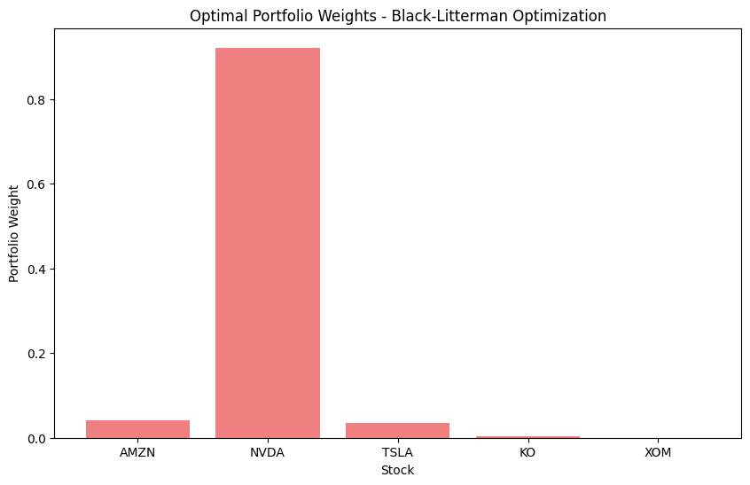

```python
plt.figure(figsize=(10, 6))
plt.bar(tickers, BL_optimal_weights, color='lightcoral')
plt.xlabel("Stock")
plt.ylabel("Portfolio Weight")
plt.title("Optimal Portfolio Weights - Black-Litterman Optimization")
plt.show()
```

```python
weights_df = pd.DataFrame({
    'Stock': tickers,
    'Markowitz_Weights': markowitz_weights,
    'BL_Weights': BL_optimal_weights
})

print("\nComparison of Portfolio Weights (Markowitz vs. Black-Litterman):")
print(weights_df)
```

```
Comparison of Portfolio Weights (Markowitz vs. Black-Litterman):
     Stock  Markowitz_Weights  BL_Weights
AMZN  AMZN           0.196583    0.040354
NVDA  NVDA           0.662931    0.921292
TSLA  TSLA           0.000000    0.034855
KO      KO           0.028911    0.003499
XOM    XOM           0.111575    0.000000
```

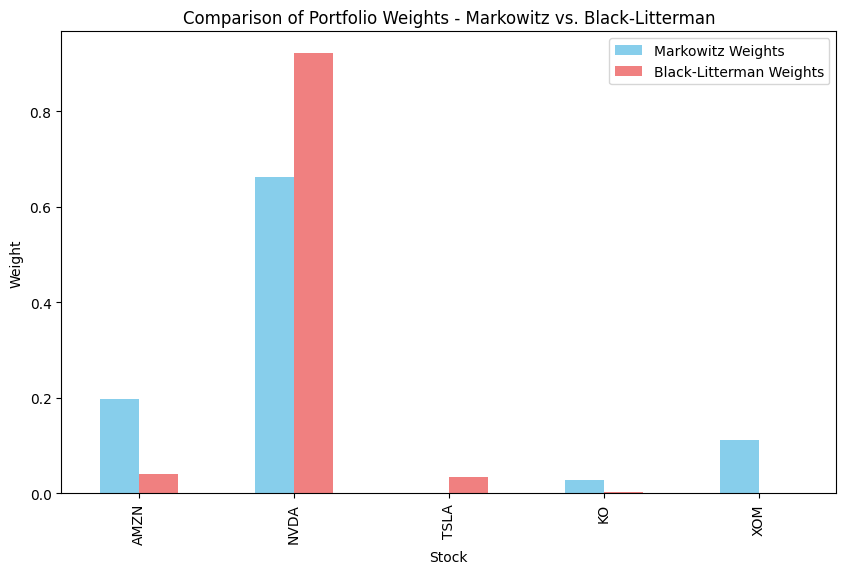

```python
weights_df.set_index('Stock').plot(kind='bar', figsize=(10, 6), color=['skyblue', 'lightcoral'])
plt.xlabel("Stock")
plt.ylabel("Weight")
plt.title("Comparison of Portfolio Weights - Markowitz vs. Black-Litterman")
plt.legend(["Markowitz Weights", "Black-Litterman Weights"])
plt.show()
```

```python
# optimal_weights = opt_result.x
optimal_return, optimal_volatility = portfolio_performance(markowitz_weights, mean_returns, cov_matrix)
optimal_sharpe = (optimal_return - risk_free_rate) / optimal_volatility

performance_df = pd.DataFrame({
    'Metric': ['Return', 'Volatility', 'Sharpe Ratio'],
    'Markowitz': [optimal_return, optimal_volatility, optimal_sharpe],
    'Black-Litterman': [BL_optimal_return, BL_optimal_volatility, BL_optimal_sharpe]
})

print("\nComparison of Portfolio Performance (Markowitz vs. Black-Litterman):")
print(performance_df)
```

```
Comparison of Portfolio Performance (Markowitz vs. Black-Litterman):
         Metric  Markowitz  Black-Litterman
0        Return   0.679818        11.589106
1    Volatility   0.127413         0.139964
2  Sharpe Ratio   5.257047        82.729025
```

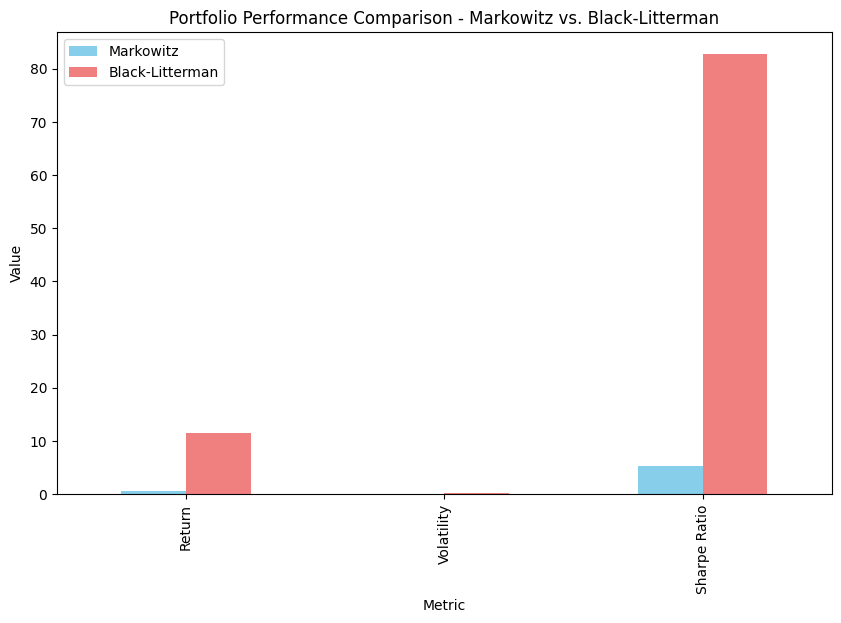

```python
performance_df.set_index('Metric').plot(kind='bar', figsize=(10, 6), color=['skyblue', 'lightcoral'])
plt.title("Portfolio Performance Comparison - Markowitz vs. Black-Litterman")
plt.ylabel("Value")
plt.legend(["Markowitz", "Black-Litterman"])
plt.show()
```

# **Step 5: Kelly Criterion**

**1. Perform back-testing using the Kelly criterion for each security in the portfolio to size the allocation to that security.**

```python
tickers = ['AMZN', 'NVDA', 'TSLA', 'KO', 'XOM']
data = yf.download(tickers, start='2021-01-01', end='2022-01-01')['Adj Close']
returns = data.pct_change().dropna()

# Calculate mean and variance of returns for each security
mean_returns = returns.mean()
variance_returns = returns.var()

# Calculate Kelly criterion weights for each stock
kelly_weights = mean_returns / variance_returns
# Normalize to sum to 1 for portfolio allocation
kelly_weights = kelly_weights / np.sum(kelly_weights)

# Calculate portfolio returns using the Kelly weights
portfolio_returns = returns.dot(kelly_weights)

# Calculate cumulative returns over the back-test period
cumulative_returns = (1 + portfolio_returns).cumprod()

# Display final results
print("Kelly Optimal Weights:", kelly_weights)
print("Final Cumulative Return Over Test Period:", cumulative_returns[-1])
```

```
[*********************100%***********************]  5 of 5 completed
```

```
Kelly Optimal Weights: Ticker
AMZN    0.062999
KO      0.354851
NVDA    0.220086
TSLA    0.084756
XOM     0.277307
dtype: float64
Final Cumulative Return Over Test Period: 1.5290944311026111
```

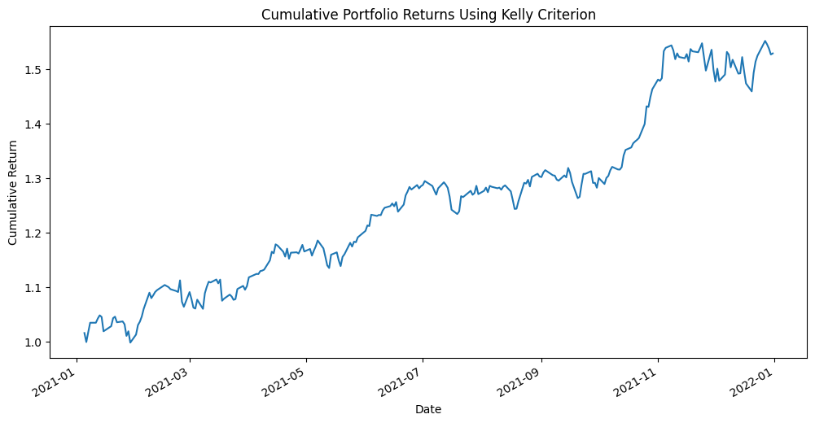

```python
# Plot cumulative returns
plt.figure(figsize=(12, 6))
cumulative_returns.plot(title="Cumulative Portfolio Returns Using Kelly Criterion")
plt.ylabel("Cumulative Return")
plt.xlabel("Date")
plt.show()
```

**2. Perform a series of historical backtests to see how the combined portfolio performs**

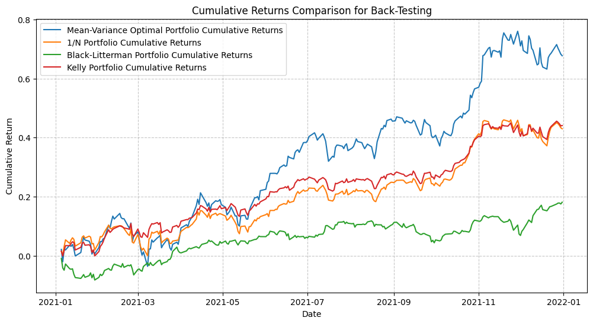

```python
# Calculate portfolio returns for different strategies
mean_var_test_returns = (returns * markowitz_weights).sum(axis=1)
one_n_weights = np.ones(len(tickers)) / len(tickers)  # Equal weight for each asset
one_n_test_returns = (returns * one_n_weights).sum(axis=1)
BL_returns = (returns * BL_optimal_weights).sum(axis=1)
kelly_returns = (returns * kelly_weights).sum(axis=1)

# Calculate cumulative returns for back-testing
cumulative_mean_var_test_returns = np.cumsum(mean_var_test_returns)
cumulative_one_n_test_returns = np.cumsum(one_n_test_returns)
cumulative_BL_returns = np.cumsum(BL_returns)
cumulative_kelly_returns = np.cumsum(kelly_returns)

# Plot the cumulative returns for each strategy
plt.figure(figsize=(12, 6))
plt.plot(cumulative_mean_var_test_returns, label='Mean-Variance Optimal Portfolio Cumulative Returns')
plt.plot(cumulative_one_n_test_returns, label='1/N Portfolio Cumulative Returns')
plt.plot(cumulative_BL_returns, label='Black-Litterman Portfolio Cumulative Returns')
plt.plot(cumulative_kelly_returns, label='Kelly Portfolio Cumulative Returns')
plt.xlabel('Date')
plt.ylabel('Cumulative Return')
plt.title('Cumulative Returns Comparison for Back-Testing')
plt.legend(loc='upper left')
plt.grid(axis='both', linestyle='--', alpha=0.7)
plt.show()
```